# Project Dool: Exploratory Data Analysis of OSRS Video Metadata

1. Introduction
2. Data Collection & Cleaning
3. Exploratory Data Analysis (EDA))
   - Video Length Analysis
   - Title Strategy
   - Upload Timing
4. Conclusion

**Note**: This is the cleaned version of the original notebook, focusing only on the outcomes of the analysis.

### Introduction

Old School RuneScape (OSRS) is a medieval fantasy MMORPG where players explore, train skills, complete quests, and fight monsters. Released in 2013 as a rerelease of the 2001 game, it’s popular for its nostalgic charm, simple gameplay, and dedicated community.

Content creators in the OSRS community produce gameplay videos and guides on platforms like YouTube and Twitch. This project analyzes the video data from these creators to find trends that can help the stakeholder expand their audience while keeping their OSRS viewers engaged.

### Purpose Statement

This project performs exploratory data analysis (EDA) on video data from popular Old School RuneScape (OSRS) content creators. The goal is to identify trends in video length, tags, titles, and upload times based on successful creators' practices. These insights could help guide future content strategies and machine learning models for predicting video performance.

### Data Collection and Cleaning

The data was extracted using Python via the YouTube API and cleaned with SQL to ensure accuracy. As first-party data, its integrity is high. Steps were taken to avoid bias, such as removing duplicates and handling missing values. The dataset focuses on successful content creators, providing relevant insights for optimizing video performance. Key metrics include titles, tags, view counts, like counts, comments, and video durations.

### Exploratory Data Analysis (EDA)

The following areas focus on exploring trends that could optimize video performance, based on the data gathered:

1. **Video Length**
   - Explore the relationship between video duration and engagement metrics (views, likes, comments), using successful creators as benchmarks.
2. **Title Strategy**
   - Investigate whether episodic naming conventions improve viewer retention.
3. **Upload Timing**
   - Identify the best times to upload videos to maximize visibility and interaction.

## Video Length Analysis

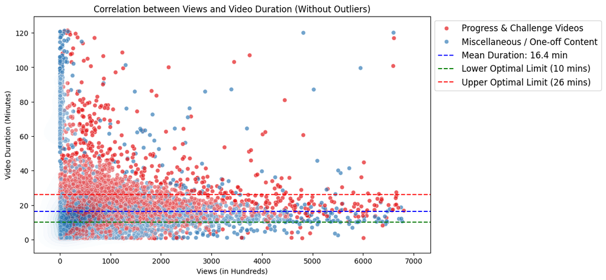

```python
# Filtered data
filtered_data = df[
    df["category"].isin(
        ["Progress & Challenge Videos", "Miscellaneous / One-off Content"]
    )
].copy()
filtered_data.loc[:, "scaled_views"] = filtered_data["views"] / 100

# Define thresholds for outliers (1st and 99th percentile)
view_lower, view_upper = np.percentile(filtered_data["scaled_views"], [1, 99])
duration_lower, duration_upper = np.percentile(
    filtered_data["duration_minutes"], [1, 99]
)

# Filter out outliers
filtered_data_no_outliers = filtered_data[
    (filtered_data["scaled_views"] >= view_lower)
    & (filtered_data["scaled_views"] <= view_upper)
    & (filtered_data["duration_minutes"] >= duration_lower)
    & (filtered_data["duration_minutes"] <= duration_upper)
]

# Calculate mean for duration
mean_duration = np.mean(filtered_data_no_outliers["duration_minutes"])

# Create scatterplot
plt.figure(figsize=(10, 6))
sns.scatterplot(
    x="scaled_views",
    y="duration_minutes",
    data=filtered_data_no_outliers,
    hue="category",
    palette="Set1",
    alpha=0.7,
)

plt.title("Correlation between Views and Video Duration (Without Outliers)")
plt.xlabel("Views (in Hundreds)")
plt.ylabel("Video Duration (Minutes)")

# Add a horizontal line for mean duration
plt.axhline(
    y=mean_duration,
    color="blue",
    linestyle="--",
    label=f"Mean Duration: {mean_duration:.1f} min",
)

# Add in horizontal lines for upper and lower optimal limits
plt.axhline(10, color="green", linestyle="--", label="Lower Optimal Limit (10 mins)")
plt.axhline(26, color="red", linestyle="--", label="Upper Optimal Limit (26 mins)")

# Use KDE plot to highlight the density of data points
sns.kdeplot(
    x="scaled_views",
    y="duration_minutes",
    data=filtered_data_no_outliers,
    cmap="Blues",
    fill=True,
    alpha=0.3,
)


# Legend
plt.legend(loc="upper left", bbox_to_anchor=(1, 1), fontsize=12)

# Show plot
plt.show()
```

The graph shows the relationship between video length and views. The average is 16 minutes, but optimal retention is likely around 14-16 minutes, accounting for intro and sponsor segments. Videos too short or long have good viewership but lower engagement compared to those in the optimal duration range. This was created using two categories from the OSRS bucket, which align with future content plans for better video length optimization.

## Title Strategy

```python
def prepare_videos_data(all_videos, series_videos):
    """
    Prepares the videos data by converting the upload date to datetime and sorting the dataframes.

    Parameters:
    - all_videos: DataFrame with all videos.
    - series_videos: DataFrame with series videos.

    Returns:
    - A tuple of processed DataFrames (all_videos, series_videos).
    """

    # Create copies to avoid modifying slices
    all_videos = all_videos.copy()
    series_videos = series_videos.copy()

    # Convert upload column to datetime
    all_videos["upload"] = pd.to_datetime(all_videos["upload"]).dt.tz_localize(None)
    series_videos["upload"] = pd.to_datetime(series_videos["upload"]).dt.tz_localize(
        None
    )

    # Sort dataframe/videos by upload date
    all_videos.sort_values(by="upload", inplace=True)
    series_videos.sort_values(by="upload", inplace=True)

    return all_videos, series_videos


def add_series_lines(series_videos, creator_data, metric="views"):
    """
    Adds vertical and horizontal lines to the plot for series start and end dates, and mean metric values.

    Parameters:
    - series_videos: DataFrame with series videos.
    - creator_data: Dictionary with creator's specific data.
    - metric: Metric to plot (views, likes, comments).
    """

    # Series details
    start_dates = creator_data["start_dates"]
    end_dates = creator_data["end_dates"]
    series_labels = creator_data["series_labels"]
    series_colors = creator_data.get(
        "series_colors", ["red", "blue", "green", "purple"]
    )

    # Add vertical lines for start and end date, if else statements for ongoing series
    for i, (start_date, end_date) in enumerate(zip(start_dates, end_dates)):
        plt.axvline(
            x=start_date,
            color=series_colors[i],
            linestyle="--",
            linewidth=2,
            label=f"{series_labels[i]} Start",
        )

        if pd.notna(end_date):
            plt.axvline(
                x=end_date,
                color=series_colors[i],
                linestyle="--",
                linewidth=2,
                label=f"{series_labels[i]} End",
            )
        else:
            # Place ongoing on line to identify series that has not finished
            plt.text(
                start_date,
                series_videos[metric].max(),
                "Ongoing",
                color=series_colors[i],
                fontsize=12,
                verticalalignment="bottom",
            )

        # Create filter to calculate the mean of each series
        series_filter = (series_videos["upload"] >= start_date) & (
            (series_videos["upload"] <= end_date) if pd.notna(end_date) else True
        )

        # Calculate the mean metric
        mean_metric = series_videos.loc[series_filter, metric].mean()

        if not pd.isna(mean_metric):
            # Horizontal line for mean metric value
            plt.hlines(
                mean_metric,
                mdates.date2num(start_date),
                mdates.date2num(end_date)
                if pd.notna(end_date)
                else mdates.date2num(series_videos["upload"].max()),
                colors=series_colors[i],
                linestyle="-",
                linewidth=2,
                label=f"{series_labels[i]} Mean",
            )


def plot_graph(all_videos, series_videos, creator_data, metric="views"):
    """
    Plots the graph with all videos and series videos, and adds vertical and horizontal lines for series data.

    Parameters:
    - all_videos: DataFrame with all videos.
    - series_videos: DataFrame with series videos.
    - creator_data: Dictionary with creator's specific data.
    - metric: Metric to plot (views, likes, comments).
    """

    # Call function to prepare video data
    all_videos, series_videos = prepare_videos_data(all_videos, series_videos)

    # Create the plot
    plt.figure(figsize=(12, 8))

    # Plot all videos
    plt.plot(
        all_videos["upload"],
        all_videos[metric],
        label="All Videos",
        color="#1f77b4",
        marker="o",
        linestyle="-",
        alpha=0.7,
    )

    # Plot series videos
    plt.plot(
        series_videos["upload"],
        series_videos[metric],
        label="Series Videos",
        color="#ff7f0e",
        marker="o",
        linestyle="-",
        alpha=0.7,
    )

    # Call function to assign horizontal and vertical lines
    add_series_lines(series_videos, creator_data, metric)

    # Format the y-axis for readability with ticker
    plt.gca().yaxis.set_major_formatter(
        ticker.FuncFormatter(lambda x, _: f"{int(x):,}")
    )

    # Customize the plot
    plt.xlabel("Upload Date")
    plt.ylabel(metric.title())  # Dynamically change label to match metric
    plt.title(f"All vs Series Video Trends: {metric.title()}")
    plt.legend()
    plt.xticks(rotation=45)
    plt.tight_layout()

    # Display the plot
    plt.show()
```

```python
# Settled's series data
settled_creator_data = {
    "start_dates": pd.to_datetime(["2018-12-21", "2022-03-27", "2024-01-27"]),
    "end_dates": pd.to_datetime(
        ["2021-12-10", "2023-11-21", None]
    ),  # None indicates ongoing series
    "series_labels": ["Swampletics", "Tileman", "Nightmare Mode"],
    "series_colors": ["red", "blue", "green"],
}
```

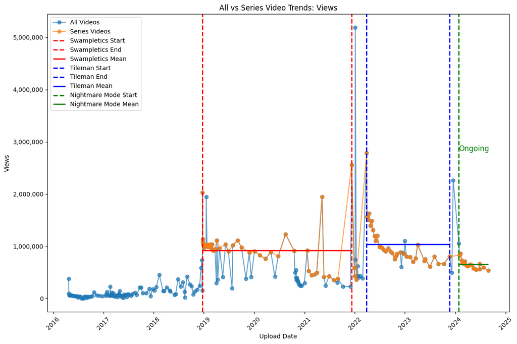

```python
# Display plot data by views
plot_graph(
    settled_all_videos, settled_series_videos, settled_creator_data, metric="views"
)
```

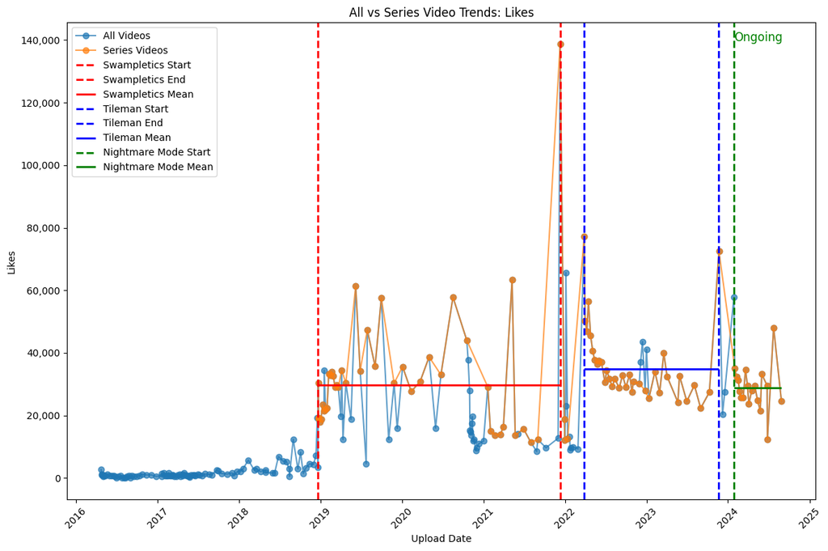

```python
# Display plot data by likes
plot_graph(
    settled_all_videos, settled_series_videos, settled_creator_data, metric="likes"
)
```

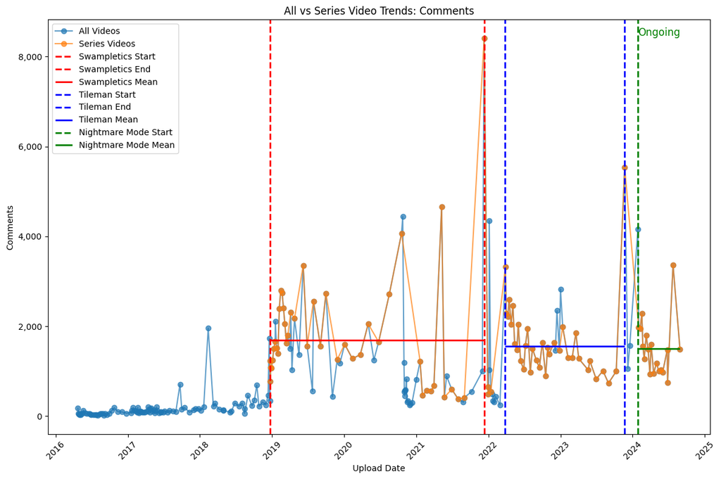

```python
# Display plot data by comments
plot_graph(
    settled_all_videos, settled_series_videos, settled_creator_data, metric="comments"
)
```

This analysis explores how title strategies impact video performance. It highlights how episodic numbering in titles builds viewer retention by creating a series that viewers want to follow. By analyzing a mix of episodic and free-form content from various creators, including some not shown here, the goal was to see if episodic numbering boosts retention and brings back viewers. This shows the impact of numbering videos in a series versus not using it.

## Upload Timing

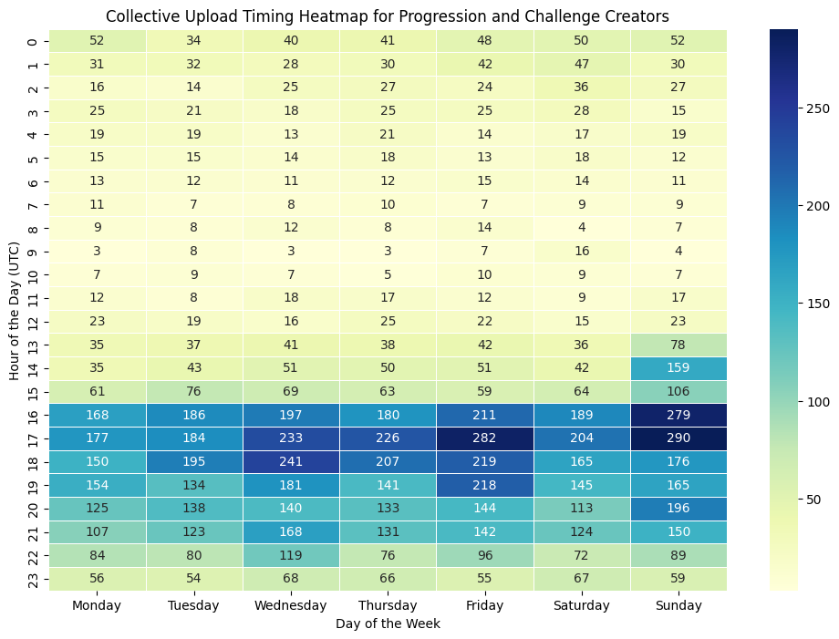

```python
# Group by day of the week and hour of upload using df_prog
upload_heatmap_data = (
    df_prog.groupby(["day", "upload_hour"]).size().reset_index(name="upload_count")
)

# Pivot the data for the heatmap
heatmap_pivot = upload_heatmap_data.pivot(
    index="upload_hour", columns="day", values="upload_count"
)

# Reorder the columns to match week order
day_order = [
    "Monday",
    "Tuesday",
    "Wednesday",
    "Thursday",
    "Friday",
    "Saturday",
    "Sunday",
]
heatmap_pivot = heatmap_pivot[day_order]

# Plot the heatmap
plt.figure(figsize=(12, 8))
sns.heatmap(heatmap_pivot, cmap="YlGnBu", annot=True, fmt="d", linewidths=0.5)
plt.title("Collective Upload Timing Heatmap for Progression and Challenge Creators")
plt.xlabel("Day of the Week")
plt.ylabel("Hour of the Day (UTC)")
plt.show()
```

```python
# Make subs numeric
df_upload["subs"] = pd.to_numeric(df_upload["subs"], errors='coerce')

# Calculate upload interval per channel
df_upload["upload_interval"] = df_upload.groupby("channel")["upload"].diff().dt.days

# Drop rows with NaN values in upload_interval
df_upload_cleaned = df_upload.dropna(subset=["upload_interval"])

# Get upload interval stats per channel
upload_frequency = df_upload_cleaned.groupby("channel")["upload_interval"].describe()

# Reset index for easier handling
upload_frequency_reset = upload_frequency.reset_index()

# Merge subs info
subs = df_upload_cleaned[['channel', 'subs']].drop_duplicates(subset="channel")
upload_frequency_with_subs = pd.merge(upload_frequency_reset, subs, on="channel", how="left")

# Sort by subs
upload_frequency_sorted = upload_frequency_with_subs.sort_values(by=["subs"], ascending=False)

# Convert to HTML
html_output = upload_frequency_sorted.to_html(index=False)

# Create scrollable table
scrollable_html = f"""
<div style="height: 300px; overflow-y: scroll; border: 1px solid #ccc;">
    {html_output}
</div>
"""

# Display
display(HTML(scrollable_html))
```

| channel | count | mean | std | min | 25% | 50% | 75% | max | subs |
| --- | --- | --- | --- | --- | --- | --- | --- | --- | --- |
| Settled | 230.0 | 12.769565 | 10.919072 | 0.0 | 6.00 | 9.0 | 18.00 | 62.0 | 717000 |
| TorvestaRS | 747.0 | 3.793842 | 5.058141 | 0.0 | 1.00 | 2.0 | 4.00 | 36.0 | 502000 |
| Framed | 1017.0 | 3.648968 | 4.814643 | 0.0 | 1.00 | 2.0 | 5.00 | 79.0 | 480000 |
| MyNameIsB0aty | 663.0 | 5.870287 | 14.887130 | 0.0 | 1.00 | 3.0 | 7.00 | 344.0 | 385000 |
| SoupRS | 947.0 | 3.954593 | 6.150255 | 0.0 | 1.00 | 2.0 | 4.00 | 71.0 | 383000 |
| J1mmy | 224.0 | 15.808036 | 18.814977 | 0.0 | 6.00 | 11.0 | 19.25 | 138.0 | 367000 |
| SirPugger | 380.0 | 9.231579 | 10.894265 | 0.0 | 3.00 | 6.0 | 12.00 | 82.0 | 353000 |
| Crumb | 200.0 | 16.135000 | 28.884222 | 0.0 | 0.00 | 4.0 | 17.25 | 174.0 | 315000 |
| C Engineer | 297.0 | 8.892256 | 8.939087 | 0.0 | 3.00 | 7.0 | 12.00 | 110.0 | 301000 |
| Solo Mission | 504.0 | 6.174603 | 19.142275 | 0.0 | 1.00 | 3.0 | 7.00 | 409.0 | 301000 |
| FlippingOldschool | 1346.0 | 1.757801 | 2.446307 | 0.0 | 0.00 | 1.0 | 2.75 | 41.0 | 278000 |
| KempQ | 246.0 | 10.747967 | 13.720590 | 0.0 | 2.00 | 6.0 | 14.00 | 91.0 | 254000 |
| Odablock | 1635.0 | 0.970031 | 3.161265 | 0.0 | 0.00 | 0.0 | 1.00 | 66.0 | 251000 |
| Theoatrix OSRS | 392.0 | 10.211735 | 39.278578 | 0.0 | 1.00 | 2.0 | 6.00 | 575.0 | 246000 |
| MrNoSleep OSRS | 525.0 | 5.455238 | 8.221434 | 0.0 | 1.00 | 3.0 | 6.00 | 74.0 | 217000 |
| Old School RuneScape | 936.0 | 3.961538 | 7.193477 | 0.0 | 1.00 | 3.0 | 6.00 | 149.0 | 213000 |
| Mr Mammal | 899.0 | 4.193548 | 3.464475 | 0.0 | 2.00 | 3.0 | 6.00 | 23.0 | 189000 |
| Slayermusiq1 | 550.0 | 7.158182 | 33.554763 | 0.0 | 1.00 | 2.0 | 5.00 | 722.0 | 186000 |
| AlkanRs | 709.0 | 5.456982 | 34.780221 | 0.0 | 0.00 | 1.0 | 5.00 | 892.0 | 184000 |
| GuidesForUsAll | 435.0 | 6.501149 | 5.382329 | 0.0 | 3.00 | 5.0 | 8.00 | 36.0 | 184000 |
| Verf | 267.0 | 10.565543 | 9.185556 | 0.0 | 4.00 | 8.0 | 15.00 | 57.0 | 161000 |
| EVScape | 789.0 | 2.934094 | 5.189380 | 0.0 | 0.00 | 1.0 | 3.00 | 49.0 | 160000 |
| Rendi | 121.0 | 32.115702 | 76.074984 | 0.0 | 9.00 | 17.0 | 26.00 | 738.0 | 155000 |
| WildMudkip | 1210.0 | 2.325620 | 11.304994 | 0.0 | 1.00 | 1.0 | 3.00 | 382.0 | 138000 |
| Link'sOcarina | 408.0 | 6.443627 | 19.399505 | 0.0 | 1.00 | 4.0 | 7.00 | 378.0 | 133000 |
| Colonello | 233.0 | 11.974249 | 13.903585 | 0.0 | 5.00 | 8.0 | 14.00 | 153.0 | 132000 |
| unsettled | 23.0 | 10.521739 | 10.299469 | 0.0 | 5.00 | 8.0 | 13.50 | 44.0 | 127000 |
| Lagunarium | 253.0 | 13.754941 | 79.257637 | 0.0 | 1.00 | 3.0 | 9.00 | 1238.0 | 126000 |
| DitterBitter | 558.0 | 3.813620 | 7.458156 | 0.0 | 1.00 | 1.0 | 4.00 | 106.0 | 123000 |
| Rargh | 418.0 | 6.796651 | 23.434982 | 0.0 | 2.00 | 5.0 | 7.00 | 473.0 | 122000 |

[output cut: 84 more lines]

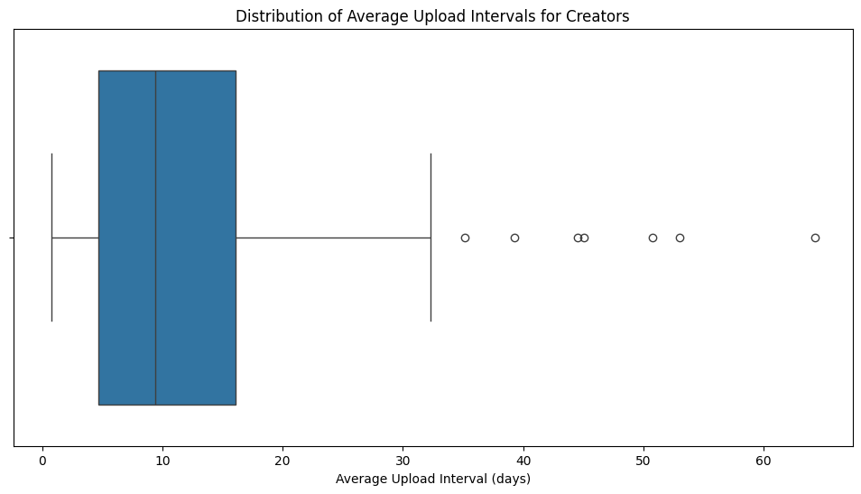

```python
"""
    Using all creators gives a broader view of upload consistency across YouTube.
    Since staying relevant is key for all creators, regardless of content type,
    this approach ensures a more comprehensive understanding of upload trends and frequency.

    A boxplot would be best to use to visualize the upper and lower limits of upload scheduling.
"""

# Group by creator and calculate the average upload interval
avg_upload_interval = (
    df_upload.groupby("channel")["upload_interval"]
    .mean()
    .reset_index(name="avg_upload_interval")
)

# Plotting the average upload interval for each creator
plt.figure(figsize=(12, 6))
sns.boxplot(x="avg_upload_interval", data=avg_upload_interval)
plt.title("Distribution of Average Upload Intervals for Creators")
plt.xlabel("Average Upload Interval (days)")
plt.show()
```

This segment looks at the best days and times to upload in the OSRS community. Most creators upload between 8 AM and 1 PM PST, with Friday and Sunday being the most common days, especially for progression content. Any day works, but A/B testing can help pinpoint the best time. Uploading around 8 AM captures early viewers, while 10 AM could catch people finishing other videos. Aim to upload every 9-10 days, avoiding intervals longer than 2 weeks to maintain relevance and consistency.

## Conclusion

### Conclusion: End of EDA for Project Dool

This EDA aimed to address the following three topics:

1. **Video Length**
   - Explored the relationship between video duration and engagement metrics (views, likes, comments), using successful creators as benchmarks.
2. **Title Strategy**
   - Investigated whether episodic naming conventions improve viewer retention.
3. **Upload Timing**
   - Identified the best times to upload videos to maximize visibility and interaction.

### Summarized Findings

1. **Video Length**
   - Ideal range: **10-26 minutes**, with **14-16 minutes** being optimal for engagement.
   - Avoid videos that are too short or too long.
2. **Title Strategy**
   - Use episodic numbering in titles to build continuity and improve viewer retention.
3. **Upload Timing**
   - Upload between **8-10 AM PST** to align with other creators.
   - **Friday and Sunday** see slightly more uploads from progression series.
   - Upload every **9-10 days**, with **2 weeks** as the maximum interval for consistency.